# Predictive Modeling for Heart Failure Prediction using Machine Learning Algorithm:

# Logistic Regression Model:

### Fit the Logistic Regression model on training set and make prediction on testing set:

```python
#Initialize the model
Lg_classifier = LogisticRegression(random_state = 42)
# Fit the model on training set
Lg_classifier.fit(X_train_scaled, y_train)
#  make prediction on testing set
y_pred_lg = Lg_classifier.predict(X_test_scaled)
```

### Evaluate the Logistic Regression model using accuracy score:

```python
accu_lg = accuracy_score(y_pred_lg, y_test)

# Print the prediction accuracy
print('Test Accuracy Logistic Regression :', accu_lg)
```

```
Test Accuracy Logistic Regression : 0.8780487804878049
```

### To get the weights of all the variables Logistic Regression:

```
AxesSubplot(0.125,0.11;0.775x0.77)
```

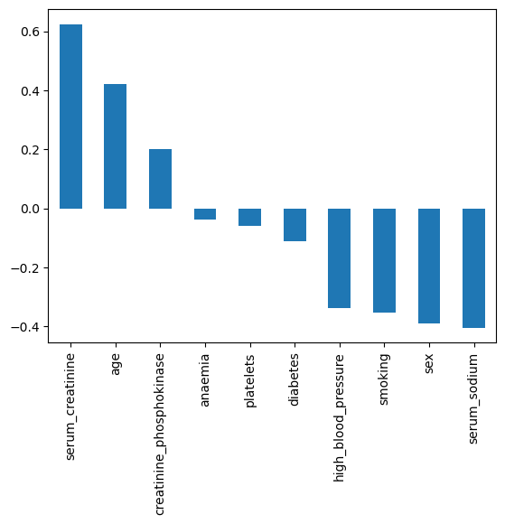

```python
weights = pd.Series(Lg_classifier.coef_[0],
                 index=X.columns.values)
print (weights.sort_values(ascending = False)[:10].plot(kind='bar'))
```

```
AxesSubplot(0.125,0.11;0.775x0.77)
```

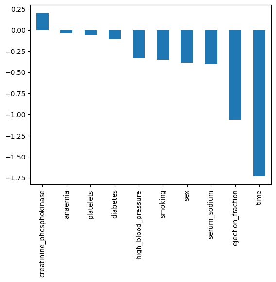

```python
print(weights.sort_values(ascending = False)[-10:].plot(kind='bar'))
```

# Decision Tree Classifier:

### Fit the Decision Tree Classifier on training set and make prediction on testing set:

```python
Dt_classifier = DecisionTreeClassifier(max_depth = 3, random_state = 42)

Dt_classifier.fit(X_train_scaled, y_train)

y_pred_dt = Dt_classifier.predict(X_test_scaled)
```

### Evaluate the Decision Tree Classifier using accuracy score:

```python
accu_dt = accuracy_score(y_pred_dt, y_test)

# Print the prediction accuracy
print('Test Accuracy Decision Tree Classifier :', accu_dt)
```

```
Test Accuracy Decision Tree Classifier : 0.7682926829268293
```

### Evaluate the Decision Tree Classifier using F1 score and AUC ROC:

```python
f1_score_dt = f1_score(y_pred_dt, y_test)

# Print the prediction accuracy
print('F1 score Decision Tree Classifier :', f1_score_dt)

roc_auc_score_dt = roc_auc_score(y_pred_dt, y_test)

# Print the prediction accuracy
print('AUC ROC Decision Tree Classifier :', roc_auc_score_dt)
```

```
F1 score Decision Tree Classifier : 0.7532467532467532
AUC ROC Decision Tree Classifier : 0.7723429951690821
```

# Random Forest Classifier:

### Fit the Random Forest Classifier on training set and make prediction on testing set:

```python
Rf_classifier = RandomForestClassifier(n_estimators = 100, random_state = 42)

Rf_classifier.fit(X_train_scaled, y_train)

y_pred_rf = Rf_classifier.predict(X_test_scaled)
```

### Evaluate the Random Forest Classifier using accuracy score:

```python
accu_rf = accuracy_score(y_pred_rf, y_test)

# Print the prediction accuracy
print('Test Accuracy Random Forest Classifier :', accu_rf)
```

```
Test Accuracy Random Forest Classifier : 0.8780487804878049
```

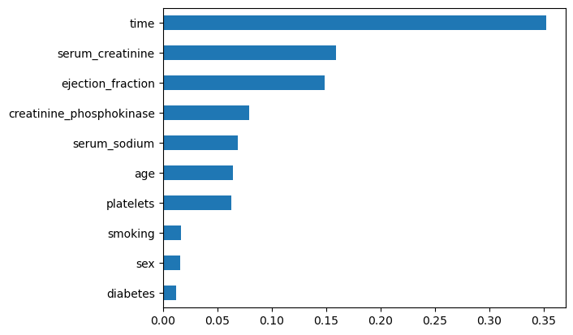

```python
importances = Rf_classifier.feature_importances_
weights = pd.Series(importances,
                 index=X.columns.values)
weights.sort_values()[-10:].plot(kind = 'barh')
```

# Support Vector Machine Classifier:

### Fit the Support Vector Machine Classifier on training set and make prediction on testing set:

```python
Svc_classifier = SVC(C = 0.01, random_state = 42)

Svc_classifier.fit(X_train_scaled, y_train)

y_pred_svc = Svc_classifier.predict(X_test_scaled)
```

### Evaluate the Support Vector Machine Classifier using accuracy score:

```python
accu_svc = accuracy_score(y_pred_svc, y_test)

# Print the prediction accuracy
print('Test Accuracy Support Vector Machine Classifier :', accu_svc)
```

```
Test Accuracy Support Vector Machine Classifier : 0.8292682926829268
```

### Evaluate the Support Vector Machine using F1 score and AUC ROC:

```python
f1_score_svc = f1_score(y_pred_svc, y_test)

# Print the prediction accuracy
print('F1 score Support Vector Machine :', f1_score_svc)

roc_auc_score_svc = roc_auc_score(y_pred_svc, y_test)

print('AUC ROC Support Vector Machine :', roc_auc_score_svc)
```

```
F1 score Support Vector Machine : 0.8205128205128206
AUC ROC Support Vector Machine : 0.8324324324324325
```

# Ada Boost Classifier:

### Fit the Ada Boost Classifier on training set and make prediction on testing set:

```python
Ab_classifier = AdaBoostClassifier(n_estimators = 10, random_state = 42)

Ab_classifier.fit(X_train_scaled, y_train)

y_pred_ab = Ab_classifier.predict(X_test_scaled)
```

### Evaluate the Ada Boost Classifier using accuracy score:

```python
accu_ab = accuracy_score(y_pred_ab, y_test)

# Print the prediction accuracy
print('Test Accuracy AdaBoost Classifier :', accu_ab)
```

```
Test Accuracy AdaBoost Classifier : 0.8780487804878049
```

### Evaluate the Ada Boost Classifier using F1 score and AUC ROC:

```python
f1_score_ab  = f1_score(y_pred_ab, y_test)

# Print the prediction f1 score
print('F1 score Ada Boost Classifier: :', f1_score_ab)

roc_auc_score_ab  = roc_auc_score(y_pred_ab, y_test)

# Print the prediction auc roc score
print('AUC ROC Ada Boost Classifier: :', roc_auc_score_ab)
```

```
F1 score Ada Boost Classifier: : 0.8780487804878049
AUC ROC Ada Boost Classifier: : 0.8780487804878049
```

# K-nearest Neighbour Classifier:

### Fit the K-nearest Neighbour Classifier on training set and make prediction on testing set:

```python
Knn_classifier = KNeighborsClassifier(n_neighbors=5)

Knn_classifier.fit(X_train_scaled, y_train)

y_pred_knn = Knn_classifier.predict(X_test_scaled)
```

### Evaluate the K-nearest Neighbour Classifier using accuracy score:

```python
accu_knn = accuracy_score(y_pred_knn, y_test)

# Print the prediction accuracy
print('Test accuracy K-nearest Neighbour Classifier :', accu_knn)
```

```
Test accuracy K-nearest Neighbour Classifier : 0.8170731707317073
```

### Evaluate the K-nearest Neighbour Classifier using F1 score and AUC ROC:

```python
f1_score_knn  = f1_score(y_pred_knn, y_test)

# Print the prediction f1 score
print('F1 score Ada Boost Classifier: :', f1_score_knn)

roc_auc_score_knn  = roc_auc_score(y_pred_knn, y_test)

# Print the prediction auc roc score
print('AUC ROC Ada Boost Classifier: :', roc_auc_score_knn)
```

```
F1 score Ada Boost Classifier: : 0.810126582278481
AUC ROC Ada Boost Classifier: : 0.81877990430622
```